# Regression & Forecasting Diagnostics: US Consumption

Bleona Krasniqi

#Simple vs Multiple Regression - U.S. Consumption

##Fit Simple Regression

```r
fit_simple <- us_change |>
  model(TSLM(Consumption ~ Income))
report(fit_simple)
```

```
## Series: Consumption
## Model: TSLM
##
## Residuals:
##      Min       1Q   Median       3Q      Max
## -2.58236 -0.27777  0.01862  0.32330  1.42229
##
## Coefficients:
##             Estimate Std. Error t value Pr(>|t|)
## (Intercept)  0.54454    0.05403  10.079  < 2e-16 ***
## Income       0.27183    0.04673   5.817  2.4e-08 ***
## ---
## Signif. codes:  0 '***' 0.001 '**' 0.01 '*' 0.05 '.' 0.1 ' ' 1
##
## Residual standard error: 0.5905 on 196 degrees of freedom
## Multiple R-squared: 0.1472,  Adjusted R-squared: 0.1429
## F-statistic: 33.84 on 1 and 196 DF, p-value: 2.4022e-08
```

##Fit Multiple Regression

```r
fit_multiple <- us_change |>
  model(multiple_lm = TSLM(Consumption ~ Income + Production + Unemployment + Savings))
report(fit_multiple)
```

```
## Series: Consumption
## Model: TSLM
##
## Residuals:
##      Min       1Q   Median       3Q      Max
## -0.90555 -0.15821 -0.03608  0.13618  1.15471
##
## Coefficients:
##               Estimate Std. Error t value Pr(>|t|)
## (Intercept)   0.253105   0.034470   7.343 5.71e-12 ***
## Income        0.740583   0.040115  18.461  < 2e-16 ***
## Production    0.047173   0.023142   2.038   0.0429 *
## Unemployment -0.174685   0.095511  -1.829   0.0689 .
## Savings      -0.052890   0.002924 -18.088  < 2e-16 ***
## ---
## Signif. codes:  0 '***' 0.001 '**' 0.01 '*' 0.05 '.' 0.1 ' ' 1
##
## Residual standard error: 0.3102 on 193 degrees of freedom
## Multiple R-squared: 0.7683,  Adjusted R-squared: 0.7635
## F-statistic:   160 on 4 and 193 DF, p-value: < 2.22e-16
```

## Interpret each coefficient in economic terms (marginal effects)

#### Simple Regression: Consumption ~ Income

The coefficients represent the estimated average percentage change in consumtion (the dependent variable) for a one-unit increase in the predictor, assuming all else remains unchanged.

For every 1% increase in disposable income, the percentage change in consumption is estimated to increase by 0.27183%.

When the percentage change in income is zero, the percentage change in consumption is 0.54454%.

#### Multiple Regression: Consumption ~ Income + Production + Unemployment + Savings

For every 1% increase in disposable income, the percentage change in consumption is estimated to increase by 0.740583%.

For every 1% increase in production, the percentage change in consumption is estimated to increase by 0.047173%.

For every 1% increase in unemployment, the percentage change in consumption is estimated to descrease by 0.174685%.

For every 1% increase in savings, the percentage change in consumption is estimated to decrease by 0.052890%.

##Compare fits, which is better and why?

The multiple regression model has a much higher Adjusted R^2, 0.7635, compared to the simple regression model, 0.1429%.

The adjusted R^2 is preferred because it accounts for the number of predictors in the model. The significant increase in the Adjusted R^2 confirms that the additional predictors provide significant explanatory power beyond just Income. This helps lead to a much better fit.

# Residual Diagnostics - Model Adequacy

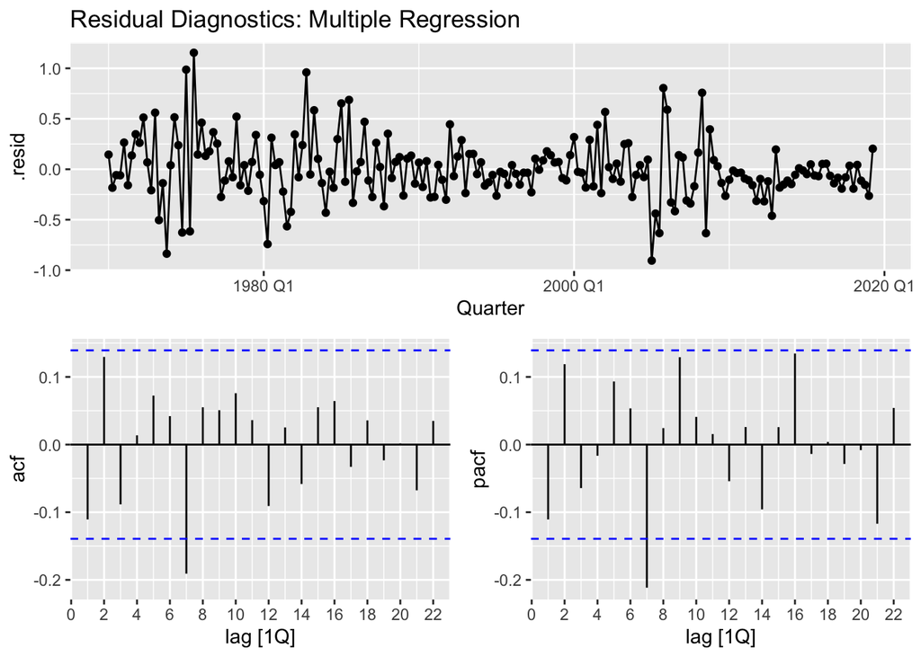

```r
resid_ts <- augment(fit_multiple) |>
  filter(.model == "multiple_lm") |>
  select(Quarter, .resid) |>
  mutate(.resid = as.numeric(.resid)) |>
  as_tsibble(index = Quarter)

resid_ts |>
  gg_tsdisplay(.resid, plot_type = "partial") +
  labs(title = "Residual Diagnostics: Multiple Regression")
```

##Plot residuals vs fitted

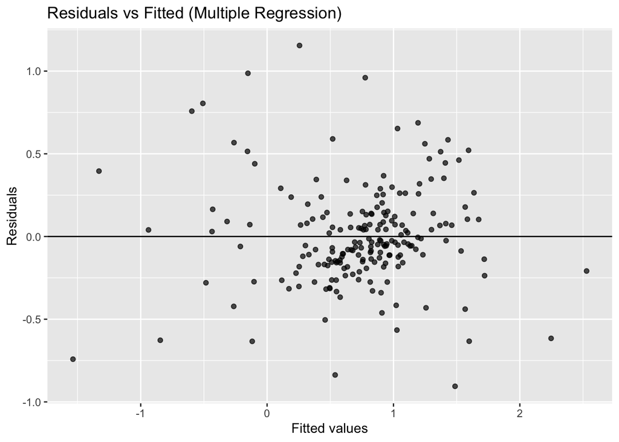

```r
resid_tbl <- augment(fit_multiple) |>
  filter(.model == "multiple_lm") |>
  select(Quarter, .fitted, .resid) |>
  as_tibble()

ggplot(resid_tbl, aes(x = .fitted, y = .resid)) +
  geom_point(alpha = 0.7) +
  geom_hline(yintercept = 0) +
  labs(
    title = "Residuals vs Fitted (Multiple Regression)",
    x = "Fitted values",
    y = "Residuals"
  )
```

The residuals appear randomly scattered around the horizontal line at zero, with no curved pattern. This suggests that the linearity assumption is satisfied as the model captures the main relationshios between predictors and consumptions.

The spread of residuals is fairly consistent across all fitted values. Therefore, there is no major sign of heteroskedasticity.

##Plot residuals vs each predictor and discuss any nonlinearity or missing-variable signals

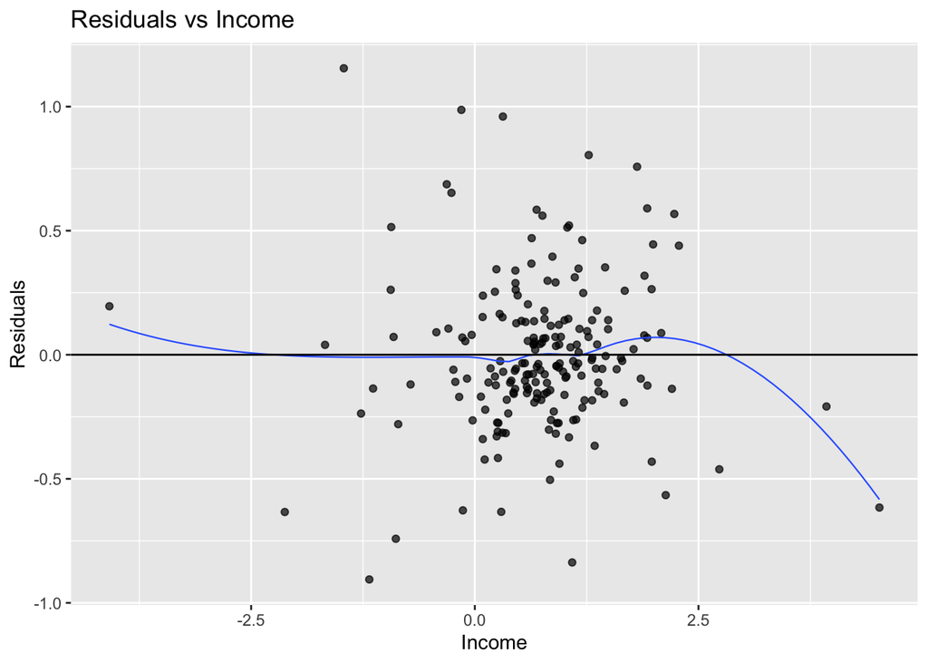

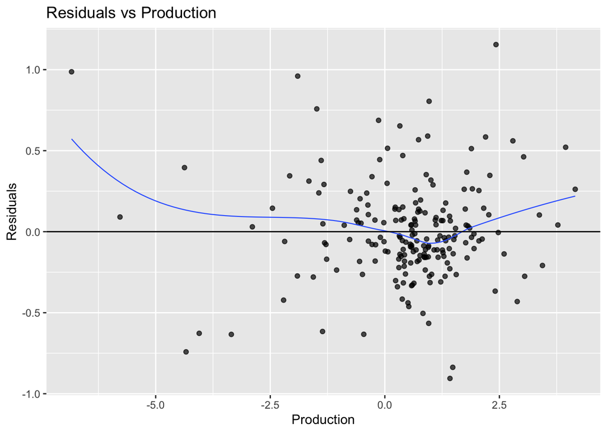

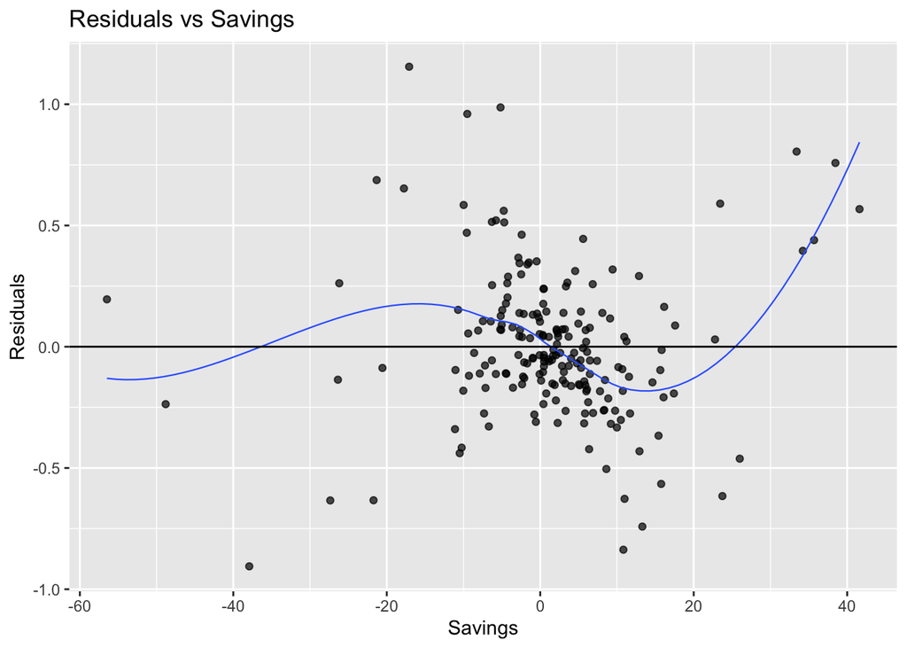

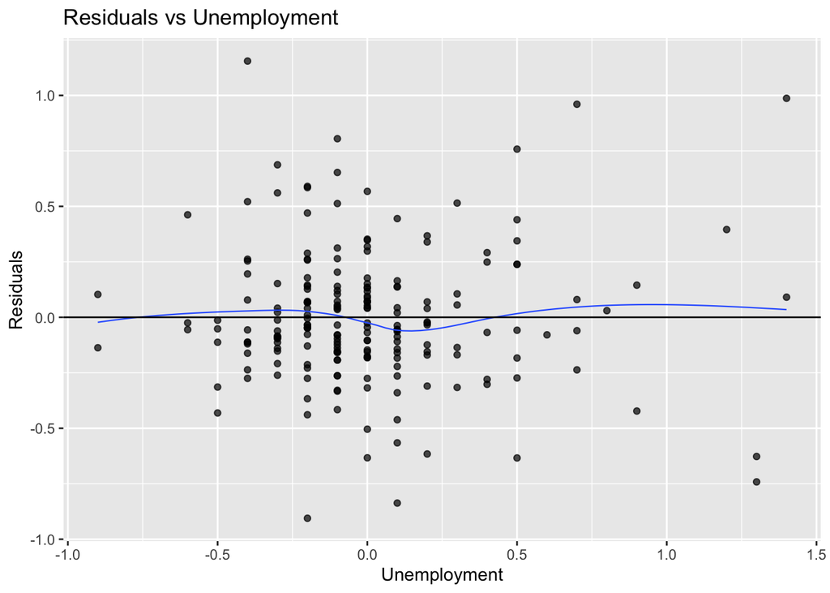

```r
resid_tbl <- augment(fit_multiple) |>
  filter(.model == "multiple_lm") |>
  select(Quarter, .resid) |>
  left_join(as_tibble(us_change), by = "Quarter") |>
  as_tibble()

preds <- c("Income", "Production", "Savings", "Unemployment")

for (p in preds) {
  print(
    ggplot(resid_tbl, aes(x = .data[[p]], y = .resid)) +
      geom_point(alpha = 0.7) +
      geom_smooth(method = "loess", se = FALSE, span = 0.8, linewidth = 0.4) +
      geom_hline(yintercept = 0) +
      labs(
        title = paste("Residuals vs", p),
        x = p,
        y = "Residuals"
      )
  )
}
```

Income: The residuals are centered near zero with no clear trend, so the linear assumption holds well.

Production: The spread looks random and evenly distributed, which means there is no sign of missing interaction or nonlinear effects.

Unemployment: The points are clustered near zero with a few outliers, but there’s no obvious trend.

# Scenario Based Forecasting - U.S. Consumption

##Take your best us_change regression from Q1

```r
fit_multiple <- us_change |>
  model(multiple_lm = TSLM(Consumption ~ Income + Production + Unemployment + Savings))
fit_best <- fit_multiple
```

Model Choice: I used the multiple regression from Q1 (Consumption ~ Income + Production + Savings + Unemployment) because it had a mich higher adjusted R^2 (0.76 vs 0.14) and a much lower residual SE than the simple model. This explains the more variation in consumption while remaining sensible: income increases, savings decreases, and unemployment decreases.

##Build two scenarios for next 4 quarters

```r
future_scenarios <- scenarios(
  # Scenario 1: Positive economic conditions
  Increase = new_data(us_change, 4) |>
    mutate(
      Income = 1,
      Savings = 0.5,
      Unemployment = 0,
      Production = 0
    ),
  # Scenario 2: Negative economic conditions
  Decrease = new_data(us_change, 4) |>
    mutate(
      Income = -1,
      Savings = -0.5,
      Unemployment = 1,
      Production = 0
    ),
  names_to = "Scenario"
)
```

##Forecast both scenarios and plot together

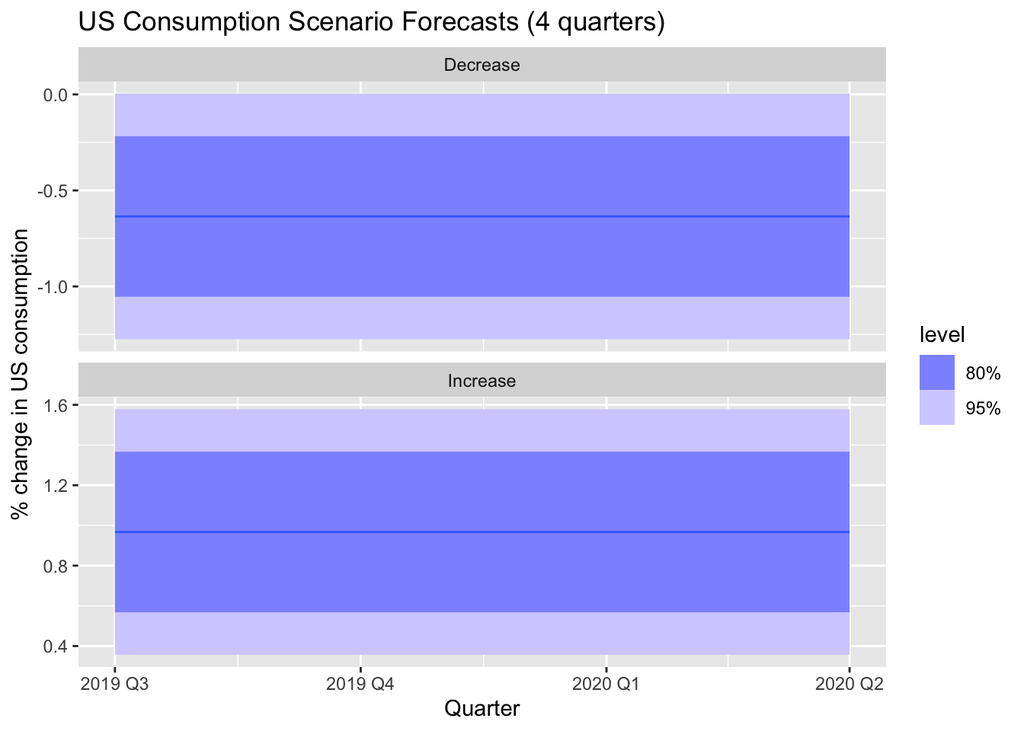

```r
fc <- forecast(fit_best, new_data = future_scenarios)

autoplot(fc) +
  labs(
    title = "US Consumption Scenario Forecasts (4 quarters)",
    y = "% change in US consumption",
    x = "Quarter"
  )
```

Since these are regression-based forecasts, they are conditional on the predictor paths.

##Interpret how economic conditions shift consumption paths.

Under Increase, consumption is higher because income and savings rise (which offsets spending) while unemployment is steady.

Under Decrease, consumption is lower because income falls, savings falls, and unemployment rises.